# sailing_analysis

2023-12-14

## Data Quality and Demographics

Participants with >20 browser interactions, >3 comprehension errors, >10 timeouts, or mean RT >5000ms are excluded from analysis after this step

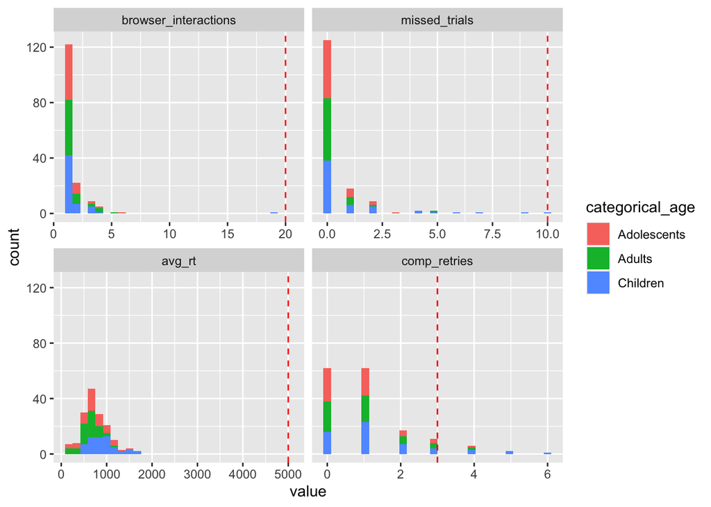

```r
data_qual <- read_csv("full_data_quality.csv")
data_qual <- melt(data_qual[,-1], id = c("categorical_age","excluded"))
cutoff_values <- data.frame(variable = unique(data_qual$variable), cutoff = c(20, 10, 5000, 3))  # Add your cutoff
ggplot(data_qual,aes(x = value, fill = categorical_age)) +
    facet_wrap(~variable,scales = "free_x") +
    geom_histogram() +
    geom_vline(data = cutoff_values, aes(xintercept = cutoff), linetype = "dashed", color = "red")
```

Age, Gender, and Race demographics data for included participants

```r
demographics_data <- read_csv("demographics_data.csv")

age_demographics <- demographics_data %>%
  group_by(categorical_age) %>%
  summarise(n = n(),
            min_age = min(Age),
            max_age = max(Age),
            mean_age = round(mean(Age),2),
            median_age = round(median(Age),2),
            n_females = sum(Gender=='Female'))
age_demographics
```

```
## # A tibble: 3 × 7
##   categorical_age     n min_age max_age mean_age median_age n_females
##   <chr>           <int>   <dbl>   <dbl>    <dbl>      <dbl>     <int>
## 1 Adolescents        51   13.0     17.9     15.3       15.2        26
## 2 Adults             51   18.2     22.7     20.6       20.9        26
## 3 Children           50    8.02    13.0     10.5       10.4        25
```

```r
race_percentages <- demographics_data %>%
  group_by(Race) %>%
  summarise(Percentage = round((n() / nrow(demographics_data) * 100),1))
race_percentages
```

```
## # A tibble: 4 × 2
##   Race                   Percentage
##   <chr>                       <dbl>
## 1 Asian                        30.3
## 2 Black/African American       13.2
## 3 Caucasian/White              43.4
## 4 Mixed Race                   13.2
```

```r
demographics_data %>%
  summarise(percent_hispanic = round(mean(Hispanic=='Y')*100,1))
```

```
## # A tibble: 1 × 1
##   percent_hispanic
##              <dbl>
## 1             15.8
```

## Full Dataset

Reading in preprocessed dataset. Each row represents a traversal trial and its preceeding boat-only trial.

- **action1TowardsPrevEnd** (1 or 0; 1 corresponds to taking action1 towards island containing prior boat; 0 is other island).
- **prior_reward** (1 or 0; 1 corresponds to reward on prior boat trial).
- **boat_neighbor_prior_reward** (1 or 0, corresponds to reward when the neighbor to the prior boat was last seen in traversal or boat-only).
- **prior_boat_choice** (1 or 0, 1 if prior boat was chosen on last visit to its island).

```r
data <- read_csv("full_data.csv")
scale_this <- function(x){
  (x - mean(x, na.rm=TRUE)) / sd(x, na.rm=TRUE)
}
data$boat_neighbor_prior_reward <- scale_this(data$boat_neighbor_prior_reward)
data$prior_boat_choice <- scale_this(data$prior_boat_choice)
data$prior_reward <- scale_this(data$prior_reward)
data$prior_island_reward <- scale_this(data$prior_island_reward)
data$block_change_congruent <- scale_this(data$block_change_congruent)
data$sub <- factor(data$sub)
data$age <- scale_this(data$age)

data$categorical_age <- factor(data$categorical_age, levels = c('Children', 'Adolescents', 'Adults'))
```

## Regressions

**Reward-only Model**

- Significant effect of **prior_reward** would suggest influence of prior boat trial on behavior in a model-based or SR-dependent manner

```r
reward_only <- glmer(action1TowardsPrevEnd ~ prior_reward * age + (prior_reward | sub),
                     data = data,
                     family = binomial,
                     control = glmerControl(optimizer = "bobyqa", optCtrl=list(maxfun=1e6)))
my_tab_model(reward_only)
```

|  | action1TowardsPrevEnd |  |  |  |
| --- | --- | --- | --- | --- |
| Predictors | Log-Odds | CI | z | p > \|z\| |
| (Intercept) | 0.11 | 0.08 – 0.15 | 6.23 | **<0.001** |
| prior reward | 0.19 | 0.15 – 0.22 | 10.06 | **<0.001** |
| age | 0.01 | -0.03 – 0.04 | 0.41 | 0.681 |
| prior reward × age | 0.01 | -0.02 – 0.05 | 0.74 | 0.457 |

```r
reward_only <- mixed(action1TowardsPrevEnd ~ prior_reward * age + (prior_reward | sub),
                        data=data, family = binomial, method="LRT")
tab_model(reward_only,
          df.method = "kenward",
          show.stat=TRUE)
```

|  | action1TowardsPrevEnd |  |  |  |
| --- | --- | --- | --- | --- |
| Predictors | Estimates | CI | Statistic | p |
| (Intercept) | 0.11 | 0.08 – 0.15 | 6.23 | **<0.001** |
| prior reward | 0.19 | 0.15 – 0.22 | 10.06 | **<0.001** |
| age | 0.01 | -0.03 – 0.04 | 0.41 | 0.681 |
| prior reward × age | 0.01 | -0.02 – 0.05 | 0.74 | 0.457 |
| Random Effects |  |  |  |  |
| σ<sup>2</sup> | 3.29 |  |  |  |
| τ<sub>00</sub> <sub>sub</sub> | 0.03 |  |  |  |
| τ<sub>11</sub> <sub>sub.prior_reward</sub> | 0.03 |  |  |  |
| ρ<sub>01</sub> <sub>sub</sub> | 0.62 |  |  |  |
| ICC | 0.02 |  |  |  |
| N <sub>sub</sub> | 152 |  |  |  |
| Marginal R<sup>2</sup> / Conditional R<sup>2</sup> | 0.010 / 0.028 |  |  |  |

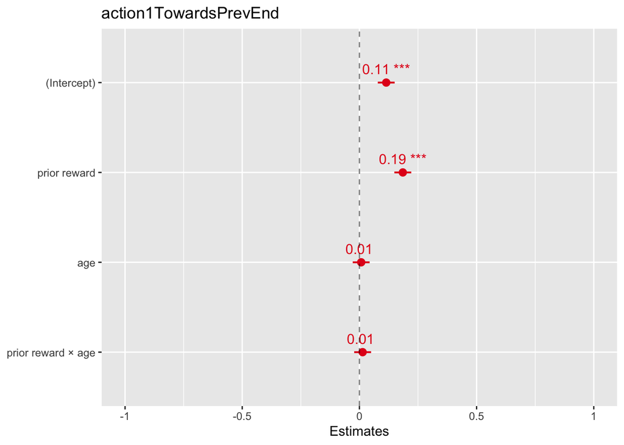

```r
plot_model(reward_only,
          show.intercept = T,
          transform = NULL,
          show.est = T,
          show.se = T,
          show.stat = T,
          show.values = T,
          show.p = T) +
  geom_hline(yintercept = 0, linetype = "dashed", alpha = .5)
```

**SR MB Interaction Model**

- Significant effect of **prior_reward** would suggest influence of prior boat trial on behavior in a model-based or SR-dependent manner.
- Significant **prior_boat_choice * prior_reward** interaction indicates SR-dependent behavior, while **prior_reward * boat_neighbor_prior_reward** interaction indicates MB-behavior. \

```r
mb_sr <- glmer(action1TowardsPrevEnd ~ prior_reward * boat_neighbor_prior_reward * prior_boat_choice * age + (prior_reward * boat_neighbor_prior_reward * prior_boat_choice | sub),
                     data = data,
                     family = binomial,
                     control = glmerControl(optimizer = "bobyqa", optCtrl=list(maxfun=1e6)))
my_tab_model(mb_sr)
```

|  | action1TowardsPrevEnd |  |  |  |
| --- | --- | --- | --- | --- |
| Predictors | Log-Odds | CI | z | p > \|z\| |
| (Intercept) | 0.03 | -0.01 – 0.07 | 1.55 | 0.120 |
| prior reward | 0.25 | 0.21 – 0.29 | 11.53 | **<0.001** |
| boat neighbor prior reward | 0.21 | 0.17 – 0.24 | 10.91 | **<0.001** |
| prior boat choice | 0.03 | -0.00 – 0.05 | 1.92 | 0.055 |
| age | -0.01 | -0.05 – 0.03 | -0.41 | 0.679 |
| prior reward × boat neighbor prior reward | -0.11 | -0.14 – -0.08 | -6.76 | **<0.001** |
| prior reward × prior boat choice | 0.12 | 0.08 – 0.15 | 6.71 | **<0.001** |
| boat neighbor prior reward × prior boat choice | -0.28 | -0.32 – -0.24 | -13.22 | **<0.001** |
| prior reward × age | 0.02 | -0.02 – 0.06 | 0.85 | 0.395 |
| boat neighbor prior reward × age | 0.03 | -0.01 – 0.07 | 1.56 | 0.119 |
| prior boat choice × age | 0.00 | -0.02 – 0.03 | 0.20 | 0.838 |
| (prior reward × boat neighbor prior reward) × prior boat choice | 0.06 | 0.03 – 0.09 | 4.35 | **<0.001** |
| (prior reward × boat neighbor prior reward) × age | -0.03 | -0.06 – 0.01 | -1.61 | 0.108 |
| (prior reward × prior boat choice) × age | 0.03 | -0.00 – 0.06 | 1.68 | 0.093 |
| (boat neighbor prior reward × prior boat choice) × age | -0.07 | -0.11 – -0.02 | -3.09 | **0.002** |
| (prior reward × boat neighbor prior reward × prior boat choice) × age | -0.00 | -0.03 – 0.03 | -0.08 | 0.938 |

```r
mb_sr <- mixed(action1TowardsPrevEnd ~ prior_reward * boat_neighbor_prior_reward * prior_boat_choice * age + (prior_reward * boat_neighbor_prior_reward * prior_boat_choice || sub),
               data = data,
               family = binomial,
               method="LRT",
               expand_re = T)
```

```r
tab_model(mb_sr,
          df.method = "kenward",
          show.stat=TRUE)
```

|  | action1TowardsPrevEnd |  |  |  |
| --- | --- | --- | --- | --- |
| Predictors | Estimates | CI | Statistic | p |
| (Intercept) | 0.03 | -0.01 – 0.07 | 1.41 | 0.160 |
| prior reward | 0.25 | 0.21 – 0.29 | 12.73 | **<0.001** |
| boat neighbor prior reward | 0.20 | 0.17 – 0.24 | 11.17 | **<0.001** |
| prior boat choice | 0.03 | -0.00 – 0.05 | 1.94 | 0.052 |
| age | -0.01 | -0.05 – 0.03 | -0.43 | 0.669 |
| prior reward × boat neighbor prior reward | -0.11 | -0.14 – -0.08 | -6.80 | **<0.001** |
| prior reward × prior boat choice | 0.12 | 0.08 – 0.15 | 6.41 | **<0.001** |
| boat neighbor prior reward × prior boat choice | -0.28 | -0.33 – -0.24 | -12.77 | **<0.001** |
| prior reward × age | 0.02 | -0.02 – 0.06 | 0.98 | 0.325 |
| boat neighbor prior reward × age | 0.03 | -0.01 – 0.06 | 1.57 | 0.116 |
| prior boat choice × age | 0.00 | -0.02 – 0.03 | 0.23 | 0.818 |
| (prior reward × boat neighbor prior reward) × prior boat choice | 0.05 | 0.03 – 0.08 | 4.00 | **<0.001** |
| (prior reward × boat neighbor prior reward) × age | -0.02 | -0.06 – 0.01 | -1.52 | 0.129 |
| (prior reward × prior boat choice) × age | 0.03 | -0.01 – 0.07 | 1.68 | 0.094 |
| (boat neighbor prior reward × prior boat choice) × age | -0.07 | -0.11 – -0.02 | -3.00 | **0.003** |
| (prior reward × boat neighbor prior reward × prior boat choice) × age | 0.00 | -0.02 – 0.03 | 0.07 | 0.946 |
| Random Effects |  |  |  |  |
| σ<sup>2</sup> | 3.29 |  |  |  |
| τ<sub>00</sub> <sub>sub</sub> | 0.04 |  |  |  |
| τ<sub>11</sub> <sub>sub.re1.prior_reward</sub> | 0.03 |  |  |  |
| τ<sub>11</sub> <sub>sub.re1.boat_neighbor_prior_reward</sub> | 0.03 |  |  |  |
| τ<sub>11</sub> <sub>sub.re1.prior_boat_choice</sub> | 0.00 |  |  |  |
| τ<sub>11</sub> <sub>sub.re1.prior_reward_by_boat_neighbor_prior_reward</sub> | 0.01 |  |  |  |
| τ<sub>11</sub> <sub>sub.re1.prior_reward_by_prior_boat_choice</sub> | 0.02 |  |  |  |
| τ<sub>11</sub> <sub>sub.re1.boat_neighbor_prior_reward_by_prior_boat_choice</sub> | 0.05 |  |  |  |
| τ<sub>11</sub> <sub>sub.re1.prior_reward_by_boat_neighbor_prior_reward_by_prior_boat_choice</sub> | 0.00 |  |  |  |
| ρ<sub>01</sub> |  |  |  |  |
| ρ<sub>01</sub> |  |  |  |  |
| ICC | 0.01 |  |  |  |
| N <sub>sub</sub> | 152 |  |  |  |
| Marginal R<sup>2</sup> / Conditional R<sup>2</sup> | 0.063 / 0.073 |  |  |  |

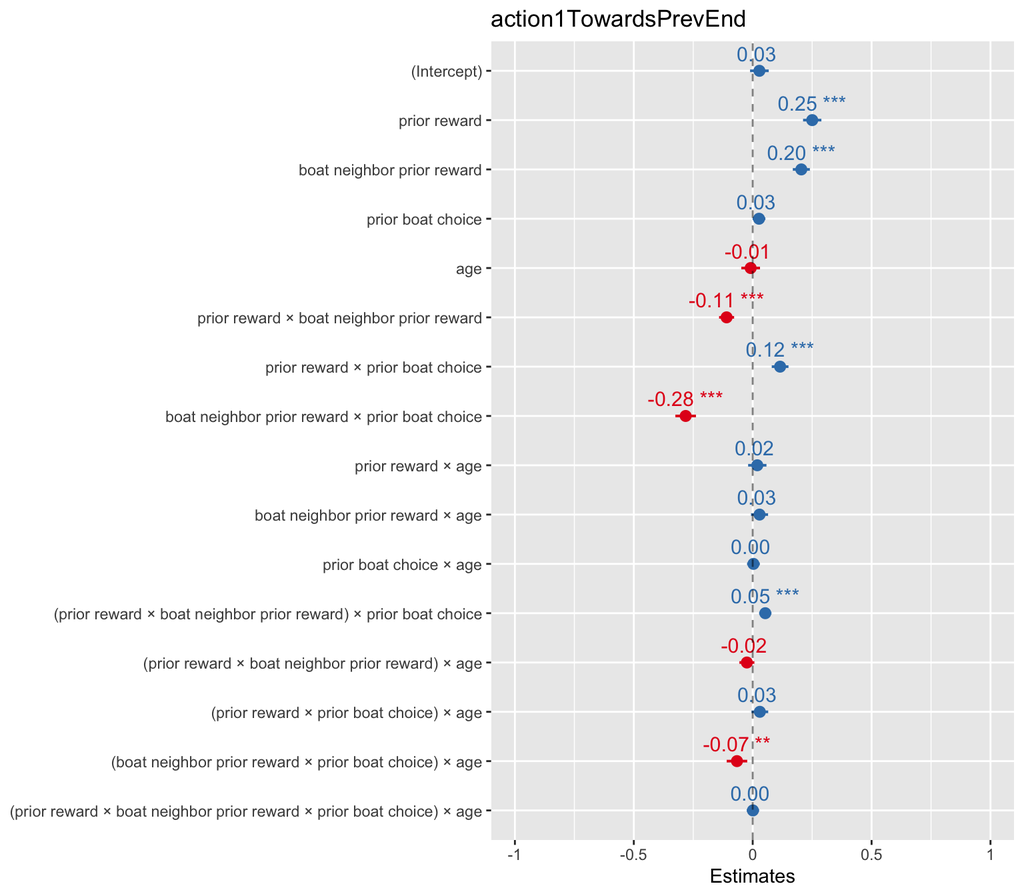

```r
plot_model(mb_sr,
          show.intercept = T,
          transform = NULL,
          show.est = T,
          show.se = T,
          show.stat = T,
          show.values = T,
          value.offset = 0.35,
          show.p = T) +
  geom_hline(yintercept = 0, linetype = "dashed", alpha = .5)
```

**SR MB Interaction Model with Block Type**

- SR MB model with additional term and its interactions
- **block_change_congruent** (1 or 0; 1 for all trials in a block following congruent block-change, 0 otherwise).

```r
mb_sr_block <- mixed(action1TowardsPrevEnd ~ prior_reward * boat_neighbor_prior_reward * prior_boat_choice * age * block_change_congruent + (prior_reward * boat_neighbor_prior_reward * prior_boat_choice * block_change_congruent || sub),
               data = data,
               family = binomial,
               method="LRT",
               expand_re = T)
```

```r
tab_model(mb_sr_block,
          df.method = "kenward",
          show.stat=TRUE)
```

|  | action1TowardsPrevEnd |  |  |  |
| --- | --- | --- | --- | --- |
| Predictors | Estimates | CI | Statistic | p |
| (Intercept) | 0.03 | -0.01 – 0.07 | 1.27 | 0.205 |
| prior reward | 0.25 | 0.21 – 0.29 | 12.75 | **<0.001** |
| boat neighbor prior reward | 0.21 | 0.17 – 0.24 | 11.15 | **<0.001** |
| prior boat choice | 0.03 | -0.00 – 0.05 | 1.92 | 0.055 |
| age | -0.01 | -0.05 – 0.03 | -0.42 | 0.676 |
| block change congruent | -0.04 | -0.06 – -0.01 | -2.63 | **0.008** |
| prior reward × boat neighbor prior reward | -0.11 | -0.14 – -0.08 | -6.66 | **<0.001** |
| prior reward × prior boat choice | 0.12 | 0.08 – 0.15 | 6.57 | **<0.001** |
| boat neighbor prior reward × prior boat choice | -0.29 | -0.33 – -0.24 | -12.89 | **<0.001** |
| prior reward × age | 0.02 | -0.02 – 0.05 | 0.81 | 0.419 |
| boat neighbor prior reward × age | 0.03 | -0.01 – 0.06 | 1.49 | 0.135 |
| prior boat choice × age | 0.00 | -0.03 – 0.03 | 0.09 | 0.929 |
| prior reward × block change congruent | 0.01 | -0.01 – 0.04 | 0.96 | 0.339 |
| boat neighbor prior reward × block change congruent | -0.03 | -0.05 – -0.00 | -1.96 | **0.050** |
| prior boat choice × block change congruent | 0.02 | -0.01 – 0.04 | 1.36 | 0.173 |
| age × block change congruent | 0.01 | -0.02 – 0.03 | 0.39 | 0.699 |
| (prior reward × boat neighbor prior reward) × prior boat choice | 0.06 | 0.03 – 0.08 | 4.05 | **<0.001** |
| (prior reward × boat neighbor prior reward) × age | -0.02 | -0.05 – 0.01 | -1.40 | 0.160 |
| (prior reward × prior boat choice) × age | 0.03 | -0.00 – 0.07 | 1.74 | 0.082 |
| (boat neighbor prior reward × prior boat choice) × age | -0.07 | -0.12 – -0.03 | -3.24 | **0.001** |
| (prior reward × boat neighbor prior reward) × block change congruent | 0.02 | -0.01 – 0.04 | 1.45 | 0.148 |
| (prior reward × prior boat choice) × block change congruent | 0.03 | -0.00 – 0.05 | 1.88 | 0.060 |
| (boat neighbor prior reward × prior boat choice) × block change congruent | -0.02 | -0.04 – 0.01 | -1.44 | 0.151 |
| (prior reward × age) × block change congruent | -0.01 | -0.04 – 0.01 | -0.95 | 0.340 |
| (boat neighbor prior reward × age) × block change congruent | -0.02 | -0.05 – 0.00 | -1.89 | 0.058 |
| (prior boat choice × age) × block change congruent | -0.01 | -0.03 – 0.02 | -0.43 | 0.668 |
| (prior reward × boat neighbor prior reward × prior boat choice) × age | 0.00 | -0.02 – 0.03 | 0.26 | 0.796 |
| (prior reward × boat neighbor prior reward × prior boat choice) × block change congruent | -0.01 | -0.04 – 0.01 | -0.91 | 0.363 |
| (prior reward × boat neighbor prior reward × age) × block change congruent | 0.01 | -0.02 – 0.03 | 0.66 | 0.509 |
| (prior reward × prior boat choice × age) × block change congruent | 0.01 | -0.02 – 0.04 | 0.75 | 0.456 |
| (boat neighbor prior reward × prior boat choice × age) × block change congruent | -0.01 | -0.03 – 0.02 | -0.67 | 0.504 |
| (prior reward × boat neighbor prior reward × prior boat choice × age) × block change congruent | -0.00 | -0.03 – 0.02 | -0.20 | 0.843 |
| Random Effects |  |  |  |  |
| σ<sup>2</sup> | 3.29 |  |  |  |
| τ<sub>00</sub> <sub>sub</sub> | 0.04 |  |  |  |
| τ<sub>11</sub> <sub>sub.re1.prior_reward</sub> | 0.03 |  |  |  |
| τ<sub>11</sub> <sub>sub.re1.boat_neighbor_prior_reward</sub> | 0.03 |  |  |  |
| τ<sub>11</sub> <sub>sub.re1.prior_boat_choice</sub> | 0.00 |  |  |  |
| τ<sub>11</sub> <sub>sub.re1.block_change_congruent</sub> | 0.00 |  |  |  |
| τ<sub>11</sub> <sub>sub.re1.prior_reward_by_boat_neighbor_prior_reward</sub> | 0.01 |  |  |  |
| τ<sub>11</sub> <sub>sub.re1.prior_reward_by_prior_boat_choice</sub> | 0.02 |  |  |  |
| τ<sub>11</sub> <sub>sub.re1.boat_neighbor_prior_reward_by_prior_boat_choice</sub> | 0.05 |  |  |  |
| τ<sub>11</sub> <sub>sub.re1.prior_reward_by_block_change_congruent</sub> | 0.00 |  |  |  |
| τ<sub>11</sub> <sub>sub.re1.boat_neighbor_prior_reward_by_block_change_congruent</sub> | 0.00 |  |  |  |
| τ<sub>11</sub> <sub>sub.re1.prior_boat_choice_by_block_change_congruent</sub> | 0.00 |  |  |  |
| τ<sub>11</sub> <sub>sub.re1.prior_reward_by_boat_neighbor_prior_reward_by_prior_boat_choice</sub> | 0.00 |  |  |  |
| τ<sub>11</sub> <sub>sub.re1.prior_reward_by_boat_neighbor_prior_reward_by_block_change_congruent</sub> | 0.00 |  |  |  |
| τ<sub>11</sub> <sub>sub.re1.prior_reward_by_prior_boat_choice_by_block_change_congruent</sub> | 0.00 |  |  |  |
| τ<sub>11</sub> <sub>sub.re1.boat_neighbor_prior_reward_by_prior_boat_choice_by_block_change_congruent</sub> | 0.00 |  |  |  |
| τ<sub>11</sub> <sub>sub.re1.prior_reward_by_boat_neighbor_prior_reward_by_prior_boat_choice_by_block_change_congruent</sub> | 0.00 |  |  |  |
| ρ<sub>01</sub> |  |  |  |  |
| ρ<sub>01</sub> |  |  |  |  |
| ICC | 0.01 |  |  |  |
| N <sub>sub</sub> | 152 |  |  |  |
| Marginal R<sup>2</sup> / Conditional R<sup>2</sup> | 0.066 / 0.076 |  |  |  |

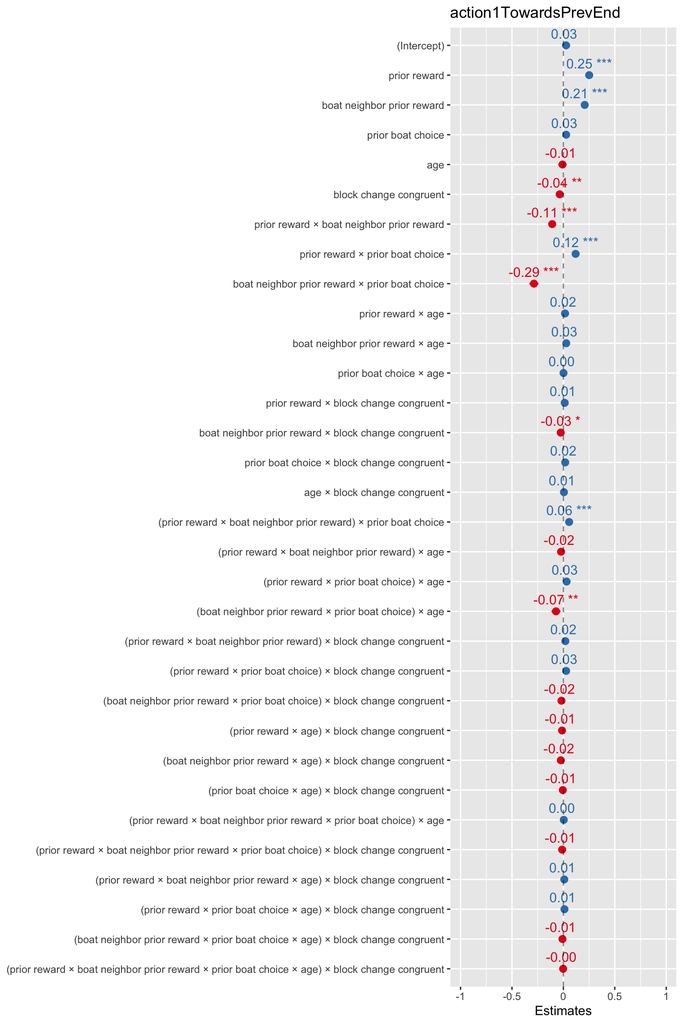

```r
plot_model(mb_sr_block,
          show.intercept = T,
          transform = NULL,
          show.est = T,
          show.se = T,
          show.stat = T,
          show.values = T,
          value.offset = 0.4,
          show.p = T) +
  geom_hline(yintercept = 0, linetype = "dashed", alpha = .5)
```

**Win-Stay-Lose-Shift Model**

- **prior_island_reward** is coded as 1 if they received a reward on the prior island and 0 if they did not.
- **repeat island** is 1 if they repeated the same island as on the previous traversal trial,

```r
wslf <- mixed(repeat_island ~ prior_island_reward * age + (prior_island_reward|sub), data=data, family = binomial, method="LRT")
tab_model(wslf,
          df.method = "kenward",
          show.stat=TRUE)
```

|  | repeat_island |  |  |  |
| --- | --- | --- | --- | --- |
| Predictors | Estimates | CI | Statistic | p |
| (Intercept) | 1.06 | 0.90 – 1.23 | 12.74 | **<0.001** |
| prior island reward | 0.73 | 0.64 – 0.81 | 16.74 | **<0.001** |
| age | 0.33 | 0.16 – 0.49 | 3.91 | **<0.001** |
| prior island reward × age | 0.19 | 0.11 – 0.28 | 4.47 | **<0.001** |
| Random Effects |  |  |  |  |
| σ<sup>2</sup> | 3.29 |  |  |  |
| τ<sub>00</sub> <sub>sub</sub> | 1.01 |  |  |  |
| τ<sub>11</sub> <sub>sub.prior_island_reward</sub> | 0.25 |  |  |  |
| ρ<sub>01</sub> <sub>sub</sub> | 0.87 |  |  |  |
| ICC | 0.28 |  |  |  |
| N <sub>sub</sub> | 152 |  |  |  |
| Marginal R<sup>2</sup> / Conditional R<sup>2</sup> | 0.130 / 0.370 |  |  |  |

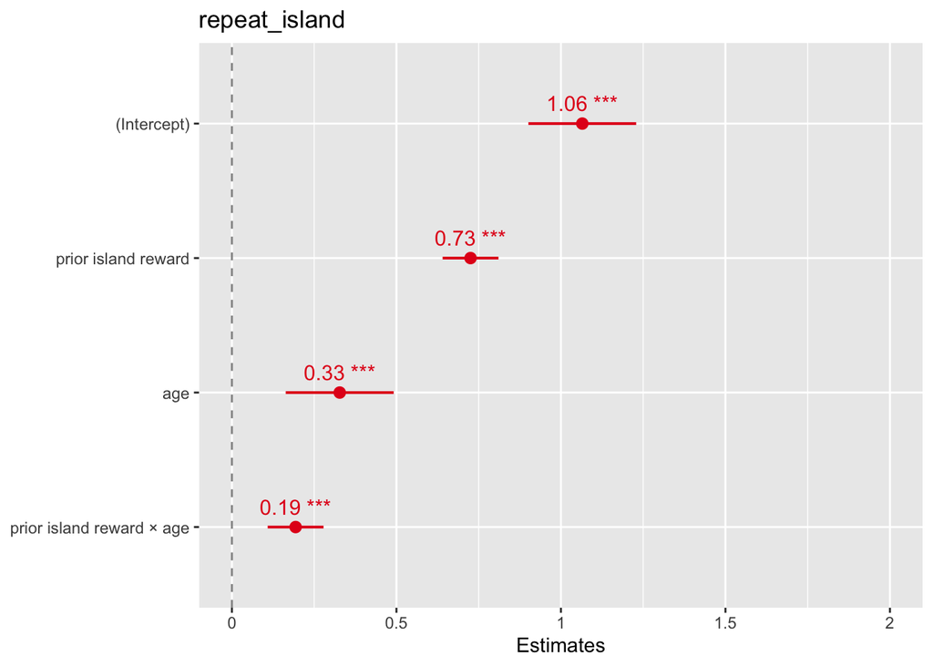

```r
plot_model(wslf,
          show.intercept = T,
          transform = NULL,
          show.est = T,
          show.se = T,
          show.stat = T,
          show.values = T,
          show.p = T) +
  geom_hline(yintercept = 0, linetype = "dashed", alpha = .5)
```

```r
# changing variables to be factors for plotting
data$prior_reward <- factor(data$prior_reward, labels=c("No Reward","Reward"))
data$boat_neighbor_prior_reward <- factor(data$boat_neighbor_prior_reward, labels=c("No Reward","Reward"))
data$prior_boat_choice <- factor(data$prior_boat_choice, labels=c("Neighboring","Observed"))
data$prior_island_reward <- factor(data$prior_island_reward, labels=c("No Reward","Reward"))
data$block_change_congruent <- factor(data$block_change_congruent, labels=c("Incongruent","Congruent"))
```

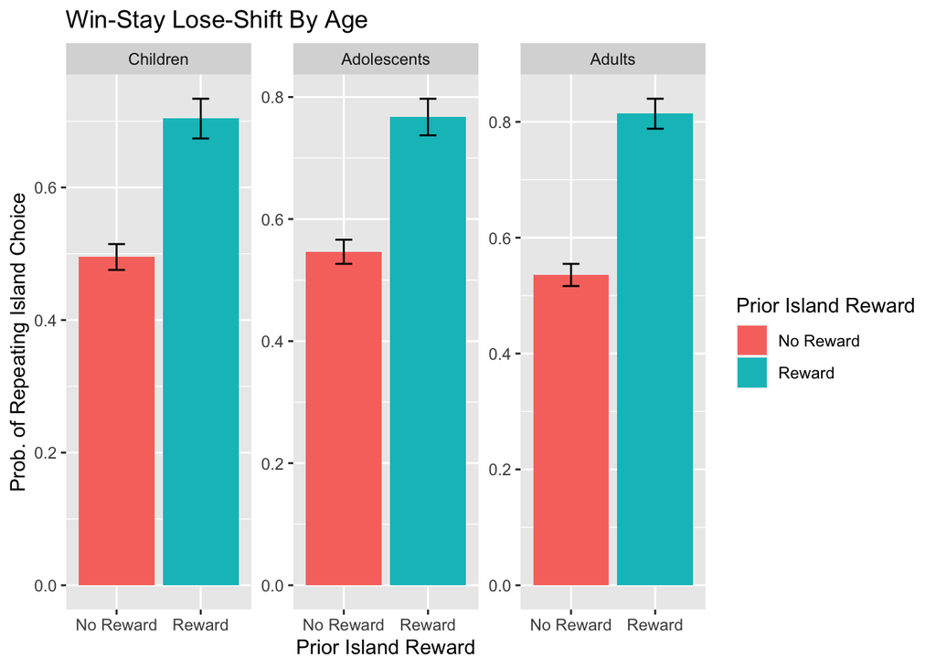

```r
wslf_per_sub <- summarySE(data, measurevar="repeat_island",
                        groupvars=c("prior_island_reward","sub","categorical_age"))
wslf_summary <- summarySE(wslf_per_sub, measurevar="repeat_island",
                        groupvars=c("prior_island_reward","categorical_age"))
wslf_summary$categorical_age <- factor(wslf_summary$categorical_age, levels = c('Children', 'Adolescents', 'Adults'))

ggplot(wslf_summary, aes(x=prior_island_reward,y=repeat_island, fill=prior_island_reward)) +
  geom_bar(stat = "identity",position="dodge") +
  geom_errorbar(aes(ymax = repeat_island + se, ymin = repeat_island - se), position=position_dodge(width = 0.9), width = 0.2)  +
  facet_wrap(~ categorical_age, scales = "free") +
  scale_fill_discrete(name = "Prior Island Reward") +
  labs(title = "Win-Stay Lose-Shift By Age",
       x = "Prior Island Reward",
       y = "Prob. of Repeating Island Choice")
```

## Plots

Original figures from paper demonstacting MB-SR interaction effects along with quick recreations.

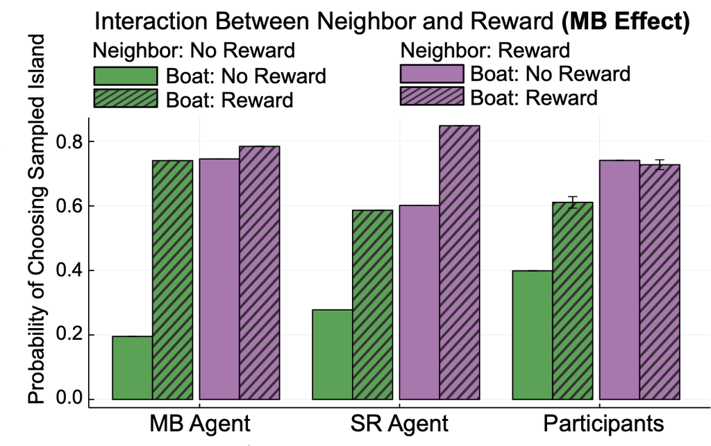

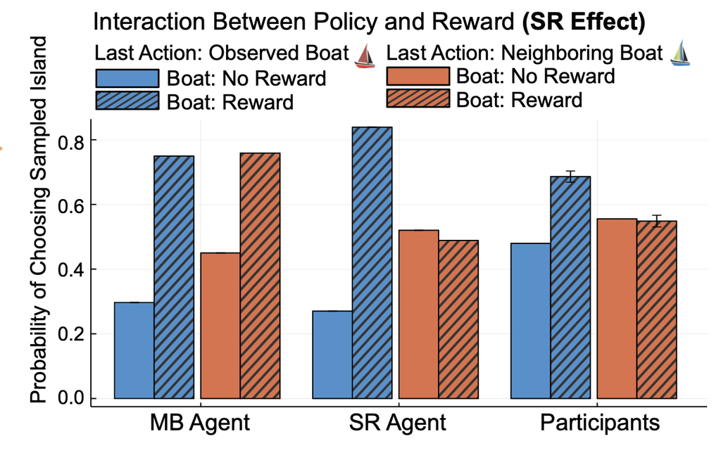

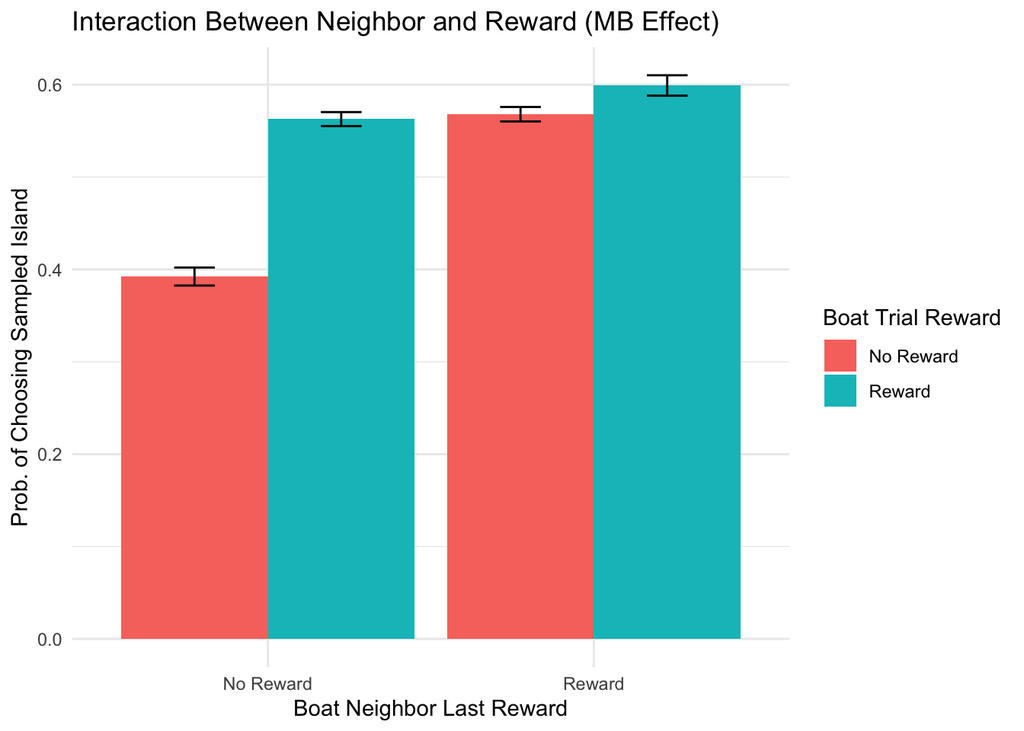

```r
summary_data <- summarySE(data, measurevar="action1TowardsPrevEnd",
                        groupvars=c("boat_neighbor_prior_reward","prior_reward","sub"))
summary_data <- summarySE(summary_data, measurevar="action1TowardsPrevEnd",
                        groupvars=c("boat_neighbor_prior_reward","prior_reward"))

ggplot(summary_data, aes(x = boat_neighbor_prior_reward, y = action1TowardsPrevEnd, fill = factor(prior_reward))) +
  geom_bar(stat = "identity", position = "dodge") +
  geom_errorbar(aes(ymin = action1TowardsPrevEnd - se, ymax = action1TowardsPrevEnd + se),
                position = position_dodge(width = 0.9), width = 0.25) +
  labs(title = "Interaction Between Neighbor and Reward (MB Effect)",
       x = "Boat Neighbor Last Reward",
       y = "Prob. of Choosing Sampled Island") +
  scale_fill_discrete(name = "Boat Trial Reward") +
  theme_minimal()
```

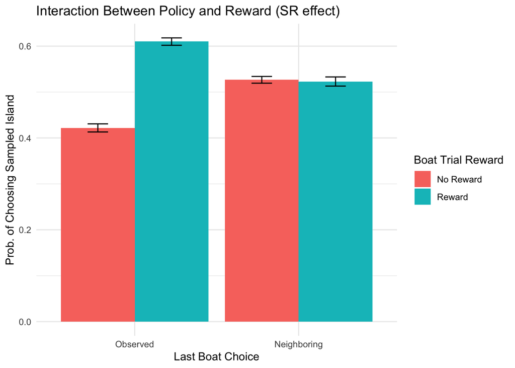

```r
summary_data <- summarySE(data, measurevar="action1TowardsPrevEnd",
                        groupvars=c("prior_boat_choice","prior_reward","sub"))
summary_data <- summarySE(summary_data, measurevar="action1TowardsPrevEnd",
                        groupvars=c("prior_boat_choice","prior_reward"))

ggplot(summary_data, aes(x = prior_boat_choice, y = action1TowardsPrevEnd, fill = factor(prior_reward))) +
  geom_bar(stat = "identity", position = "dodge") +
  geom_errorbar(aes(ymin = action1TowardsPrevEnd - se, ymax = action1TowardsPrevEnd + se),
                position = position_dodge(width = 0.9), width = 0.25) +
  labs(title = "Interaction Between Policy and Reward (SR effect)",
       x = "Last Boat Choice",
       y = "Prob. of Choosing Sampled Island") +
  scale_fill_discrete(name = "Boat Trial Reward") +
  theme_minimal() +
  scale_x_discrete(limits=rev)
```

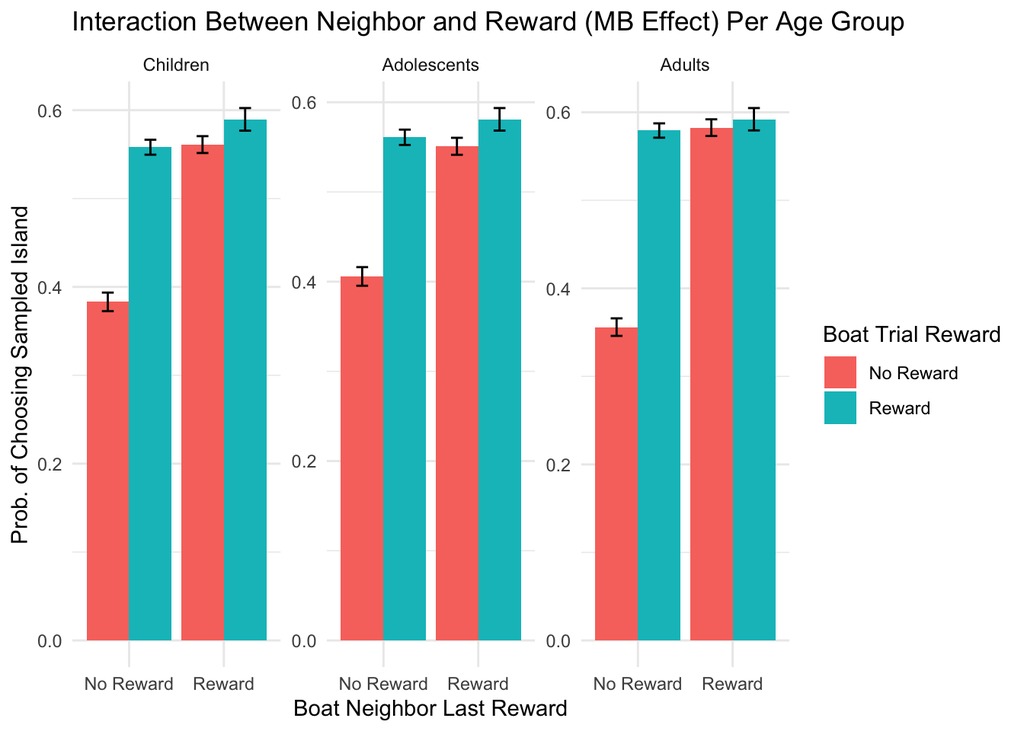

```r
summary_data <- summarySE(data, measurevar="action1TowardsPrevEnd",
                        groupvars=c("boat_neighbor_prior_reward","prior_reward","sub","categorical_age"))
summary_data <- summarySE(data, measurevar="action1TowardsPrevEnd",
                        groupvars=c("boat_neighbor_prior_reward","prior_reward","categorical_age"))

ggplot(summary_data, aes(x = boat_neighbor_prior_reward, y = action1TowardsPrevEnd, fill = prior_reward)) +
  geom_bar(stat = "identity", position = "dodge") +
  geom_errorbar(aes(ymin = action1TowardsPrevEnd - se, ymax = action1TowardsPrevEnd + se),
                position = position_dodge(width = 0.9), width = 0.25) +
  labs(title = "Interaction Between Neighbor and Reward (MB Effect) Per Age Group",
       x = "Boat Neighbor Last Reward",
       y = "Prob. of Choosing Sampled Island") +
  scale_fill_discrete(name = "Boat Trial Reward") +
  facet_wrap(~ categorical_age, scales = "free") +
  theme_minimal()
```

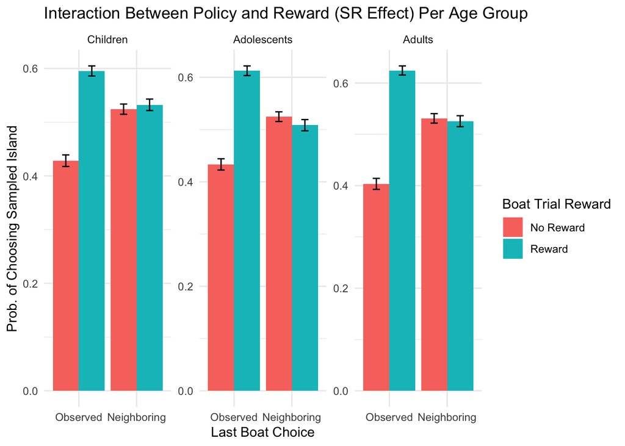

```r
summary_data <- summarySE(data, measurevar="action1TowardsPrevEnd",
                        groupvars=c("prior_boat_choice","prior_reward","sub","categorical_age"))
summary_data <- summarySE(data, measurevar="action1TowardsPrevEnd",
                        groupvars=c("prior_boat_choice","prior_reward","categorical_age"))

ggplot(summary_data, aes(x = prior_boat_choice, y = action1TowardsPrevEnd, fill = prior_reward)) +
  geom_bar(stat = "identity", position = "dodge") +
  geom_errorbar(aes(ymin = action1TowardsPrevEnd - se, ymax = action1TowardsPrevEnd + se),
                position = position_dodge(width = 0.9), width = 0.25) +
  labs(title = "Interaction Between Policy and Reward (SR Effect) Per Age Group",
       x = "Last Boat Choice",
       y = "Prob. of Choosing Sampled Island") +
  scale_fill_discrete(name = "Boat Trial Reward") +
  facet_wrap(~ categorical_age, scales = "free") +
  theme_minimal() +
  scale_x_discrete(limits=rev)
```

** Plots to visualize interaction effects from SR-MB + Block Type model. **

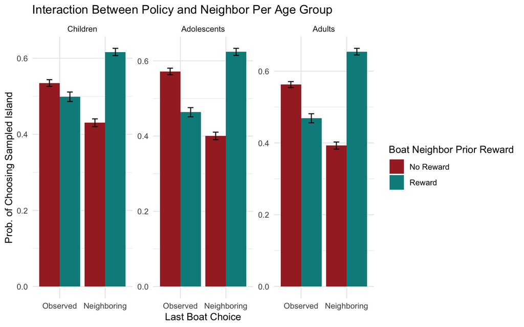

```r
summary_data <- summarySE(data, measurevar="action1TowardsPrevEnd",
                        groupvars=c("prior_boat_choice","boat_neighbor_prior_reward","sub","categorical_age"))
summary_data <- summarySE(data, measurevar="action1TowardsPrevEnd",
                        groupvars=c("prior_boat_choice","boat_neighbor_prior_reward","categorical_age"))

ggplot(summary_data, aes(x = prior_boat_choice, y = action1TowardsPrevEnd, fill = boat_neighbor_prior_reward)) +
  geom_bar(stat = "identity", position = "dodge") +
  geom_errorbar(aes(ymin = action1TowardsPrevEnd - se, ymax = action1TowardsPrevEnd + se),
                position = position_dodge(width = 0.9), width = 0.25) +
  labs(title = "Interaction Between Policy and Neighbor Per Age Group",
       x = "Last Boat Choice",
       y = "Prob. of Choosing Sampled Island") +
  scale_fill_manual(name = "Boat Neighbor Prior Reward", values=c("brown","darkcyan")) +
  facet_wrap(~ categorical_age, scales = "free") +
  theme_minimal() +
  scale_x_discrete(limits=rev)
```

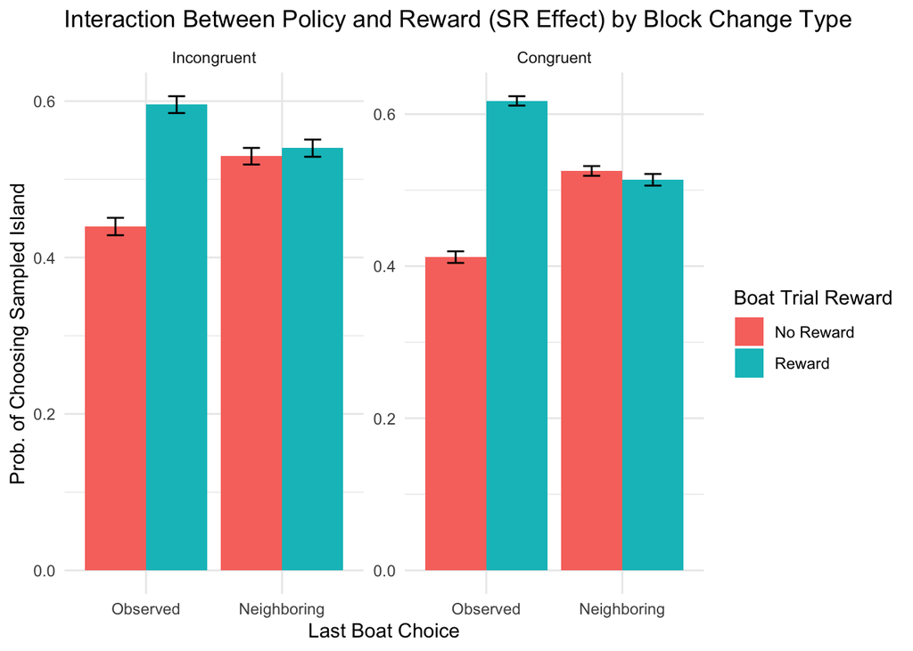

```r
summary_data <- summarySE(data, measurevar="action1TowardsPrevEnd",
                        groupvars=c("prior_boat_choice","prior_reward","sub","block_change_congruent"))
summary_data <- summarySE(data, measurevar="action1TowardsPrevEnd",
                        groupvars=c("prior_boat_choice","prior_reward","block_change_congruent"))
summary_data <- drop_na(summary_data)
summary_data$prior_boat_choice <- factor(summary_data$prior_boat_choice, levels = c("Observed", "Neighboring"))
ggplot(summary_data, aes(x = prior_boat_choice, y = action1TowardsPrevEnd, fill = prior_reward)) +
  geom_bar(stat = "identity", position = "dodge") +
  geom_errorbar(aes(ymin = action1TowardsPrevEnd - se, ymax = action1TowardsPrevEnd + se),
                position = position_dodge(width = 0.9), width = 0.25) +
  labs(title = "Interaction Between Policy and Reward (SR Effect) by Block Change Type",
       x = "Last Boat Choice",
       y = "Prob. of Choosing Sampled Island") +
  scale_fill_discrete(name = "Boat Trial Reward") +
  facet_wrap(~ block_change_congruent, scales = "free") +
  theme_minimal()
```

```r
  scale_x_discrete(limits=rev)
```

[output not shown]

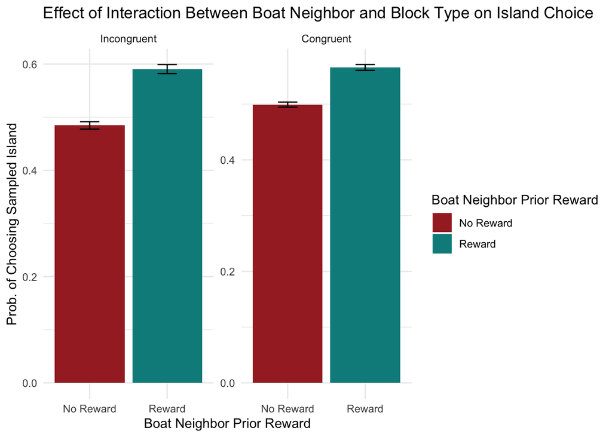

```r
summary_data <- summarySE(data, measurevar="action1TowardsPrevEnd",
                        groupvars=c("boat_neighbor_prior_reward","sub","block_change_congruent"))
summary_data <- summarySE(data, measurevar="action1TowardsPrevEnd",
                        groupvars=c("boat_neighbor_prior_reward","block_change_congruent"))
summary_data <- drop_na(summary_data)

ggplot(summary_data, aes(x = boat_neighbor_prior_reward, y = action1TowardsPrevEnd, fill=boat_neighbor_prior_reward)) +
  geom_bar(stat = "identity", position = "dodge") +
  geom_errorbar(aes(ymin = action1TowardsPrevEnd - se, ymax = action1TowardsPrevEnd + se),
                position = position_dodge(width = 0.9), width = 0.25) +
  labs(title = "Effect of Interaction Between Boat Neighbor and Block Type on Island Choice",
       x = "Boat Neighbor Prior Reward",
       y = "Prob. of Choosing Sampled Island") +
  scale_fill_manual(name = "Boat Neighbor Prior Reward", values=c("brown","darkcyan")) +
  facet_wrap(~ block_change_congruent, scales = "free") +
  theme_minimal()
```

```r
  scale_x_discrete(limits=rev)
```

[output not shown]